```python
from math import log
import numpy as np
import matplotlib.pyplot as plt
from scipy.integrate import odeint
```

# Problem 1

The odeint solver requires a callable function representing the right hand side of the IVP. Define the function predator_prey() that accepts the current r(t) and w(t) values as a 1d array y, and the current time t, and returns the right hand side of the predator-prey model as a tuple. Use $\alpha$ = 1.0, $\beta$ = 0.5, $\delta$ = 0.75, and $\gamma$ = 0.25 as your growth parameters.

```python
def predator_prey(y, t):
    """Compute right hand side of Predator-Prey model based on rabbit and
    wolf populations at given time.

    Parameters:
        y ((2, ) ndarray): A vector representing rabbit and wolf populations
            at time t.
        t (float): Current time.

    Returns:
        (tuple): A tuple corresponding to right hand side of the Predator-
            Prey model.
    """
    # Constants in equation
    alpha, beta, delta, gamma = 1.0, 0.5, 0.75, 0.25
    # Rabbits and wolves populations
    r, w = y[0], y[1]
    return (r * (alpha - beta * w), w * (-delta + gamma * r))
```

# Problem 2

Use odeint to solve the predator-prey model ODE with initial conditions (r0 , w0 ) = (5, 3) and time ranging from 0 to 20 years. Display the resulting rabbit and wolf populations over time (stored as columns in the output of odeint) on the same plot.

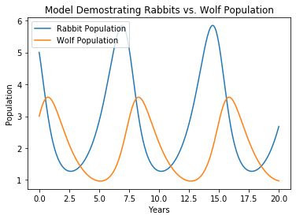

```python
y0 = (5,3)
t = np.linspace(0, 20, 1000)

# Compute solution
sol = odeint(predator_prey, y0, t)

# Graph solution
plt.plot(t, sol[:,0], label="Rabbit Population")
plt.plot(t, sol[:,1], label="Wolf Population")
plt.title("Model Demostrating Rabbits vs. Wolf Population")
plt.xlabel("Years")
plt.ylabel("Population")
plt.legend()
plt.show()
```

# Problem 3

Similar to problem 1, define the function Lotka_volterra() that takes in the current preditor and prey populations as a 1d array y and the current time as a float t and returns the right hand side of the Lotka-Volterra predator-prey model with $\eta$ = 1/3.

Using odeint, solve the IVP with three different initial conditions $y_0 = (1/2, 1/3)$, $y_0 = (1/2, 3/4)$, and $y_0 = (1/16, 3/4)$ and time domain $t = [0, 13]$. Plot these three solutions on the same graph as the phase portrait and the equilibria (0, 0) and (1, 1).

Since your solutions are being plotted with the phase portrait, plot the two populations against eachother (instead of both individually against time).

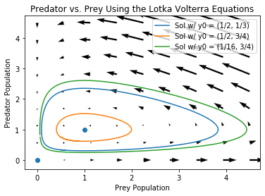

```python
def Lotka_Volterra(y, t):
    """Compute right hand side of Lotka Volterra Predator-Prey model based
    on rabbit and wolf populations at given time.

    Parameters:
        y ((2, ) ndarray): A vector representing rabbit and wolf populations
            at time t.
        t (float): Current time.

    Returns:
        (tuple): A tuple corresponding to right hand side of the Lotka
            Volterra Predator-Prey model.
    """
    n = 1/3
    u, v = y
    return (u * (1 - v), n * v * (u - 1))

# Provided code for plotting phase portrait.
Y1, Y2 = np.meshgrid(np.linspace(0,4.5,25), np.linspace(0,4.5,25))
dU, dV = Lotka_Volterra((Y1, Y2), 0)
Q = plt.quiver(Y1[::3, ::3],Y2[::3, ::3],dU[::3, ::3],dV[::3, ::3])

y0 = (1/2, 1/3)
y1 = (1/2, 3/4)
y2 = (1/16, 3/4)
t = np.linspace(0, 13, 1000)

# Compute solutions
sol1 = odeint(Lotka_Volterra, y0, t)
sol2 = odeint(Lotka_Volterra, y1, t)
sol3 = odeint(Lotka_Volterra, y2, t)

# Graph all the solutions
plt.plot(sol1[:, 0], sol1[:,1], label="Sol w/ y0 = (1/2, 1/3)")
plt.plot(sol2[:, 0], sol2[:,1], label="Sol w/ y0 = (1/2, 3/4)")
plt.plot(sol3[:, 0], sol3[:,1], label="Sol w/ y0 = (1/16, 3/4)")
plt.scatter([0,1],[0,1])
plt.title("Predator vs. Prey Using the Lotka Volterra Equations")
plt.xlabel("Prey Population")
plt.ylabel("Predator Population")
plt.legend()
plt.show()
```

# Problem 4

Define a new function Logistic_Model() that takes in the current preditor and prey populations y and the current time t and returns the right hand side of the logistic predator-prey model as a tuple.

Use odeint to compute solutions (U, V) of (1.3) for initial conditions (1/3, 1/3) and (1/2, 1/5). Do this for parameter values $\eta$, $\rho$ = 1, 0.3 and also for values $\eta$, $\rho$ = 1, 1.1.

Create a phase portrait for the logistic equations using both sets of parameter values. Plot the direction field, all equilibrium points, and both solution orbits on the same plot for each set of parameter values.

```python
def get_logistic_model(n, p):
    def Logistic_Model(y, t):
        """Compute right hand side of Logistic Predator-Prey model based on
        rabbit and wolf populations at given time.

        Parameters:
            y ((2, ) ndarray): A vector representing rabbit and wolf populations
                at time t.
            t (float): Current time.

        Returns:
            (tuple): A tuple corresponding to right hand side of the Logistic
                Predator-Prey model.
        """
        u, v = y[0], y[1]
        return (u * (1 - u - v), n * v * (u - p))

    return Logistic_Model
```

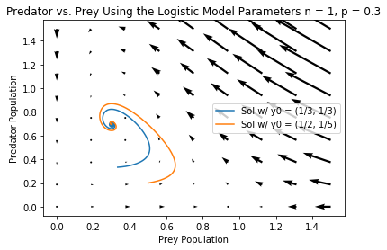

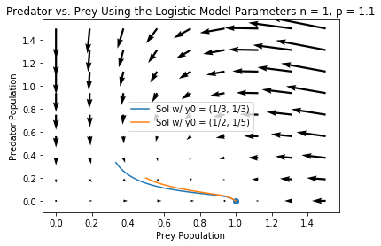

```python
y0 = (1/3, 1/3)
y1 = (1/2, 1/5)
t = np.linspace(0, 50, 1000)
# Define functions with given parameters
logistic_model1 = get_logistic_model(1, 0.3)
logistic_model2 = get_logistic_model(1, 1.1)

# Plot Phase Portrait for 1st Set of Parameters, and Plot Solution
Y1, Y2 = np.meshgrid(np.linspace(0,1.5,25), np.linspace(0,1.5,25))
dU, dV = logistic_model1((Y1, Y2), 0)
plt.figure(0)
plt.quiver(Y1[::3, ::3],Y2[::3, ::3],dU[::3, ::3],dV[::3, ::3])

sol1 = odeint(logistic_model1, y0, t)
sol2 = odeint(logistic_model1, y1, t)
plt.plot(sol1[:, 0], sol1[:,1], label="Sol w/ y0 = (1/3, 1/3)")
plt.plot(sol2[:, 0], sol2[:,1], label="Sol w/ y0 = (1/2, 1/5)")
plt.scatter(0.3,0.7)
plt.title("Predator vs. Prey Using the Logistic Model Parameters n = 1, p = 0.3")
plt.xlabel("Prey Population")
plt.ylabel("Predator Population")
plt.legend()
plt.show()

# Plot Phase Portrait for 2nd Set of Parameters and Plot Solution
plt.figure(1)
dU, dV = logistic_model2((Y1, Y2), 0)
plt.quiver(Y1[::3, ::3],Y2[::3, ::3],dU[::3, ::3],dV[::3, ::3])

sol1 = odeint(logistic_model2, y0, t)
sol2 = odeint(logistic_model2, y1, t)
plt.plot(sol1[:, 0], sol1[:,1], label="Sol w/ y0 = (1/3, 1/3)")
plt.plot(sol2[:, 0], sol2[:,1], label="Sol w/ y0 = (1/2, 1/5)")
plt.scatter(1,0)
plt.title("Predator vs. Prey Using the Logistic Model Parameters n = 1, p = 1.1")
plt.xlabel("Prey Population")
plt.ylabel("Predator Population")
plt.legend()
plt.show()
```

# Problem 5

Using forbes() and energy_balance(), define the function weight_odesystem() which takes as input the current fat and lean weights as an array y and the current time as a float t and return the right hand side of the weight change ODE as a tuple.

```python
# Set Constants
gamma_f, gamma_l, nf, nl, beta_AT = 3.2, 22, 180, 230, 0.14
pl, pf = 1800, 9400
EI_0 = 2143
EI = 2025
PAL_0 = 1.4
PAL = 1.5

def forbes(F):
    C = (10.4 * pl) / pf
    return C / (C + F)

def energy_balance(F, L, PAL, EI):
    numer = (1 / PAL - beta_AT) * EI - K - gamma_f * F - gamma_l * L
    denom = (nf / pf) * (1 - forbes(F)) + (nl / pl) * forbes(F) + 1 / PAL
    return numer / denom

def weight_odesystem(y, t):
    F, L = y
    first_entry = ((1 - forbes(F)) * energy_balance(F, L, PAL, EI)) / pf
    second_entry = forbes(F) * energy_balance(F, L, PAL, EI) / pl
    return (first_entry, second_entry)
```

# Problem 6

Consider the initial value problem corresponing to (1.4).

$\frac{dL}{dt} = \frac{p(t)EB(t)}{\rho_L}$,

$F(0) = F_0$,

$L(0) = L_0$.

Use the original intake and phyical activity levels to compute K for this system. Then use odeint to solve the IVP. Graph the solution curve for this single-stage weightloss intervention over a period of 5 years.

Note the provided code requires quantities in metric units (kilograms, meters, days).

```python
# Provided function.
def fat_mass(BW, age, H, sex):
    BMI = BW / H**2.
    if sex == 'male':
        return BW * (-103.91 + 37.31 * log(BMI) + 0.14 * age) / 100
    else:
        return BW * (-102.01 + 39.96 * log(BMI) + 0.14 * age) / 100
```

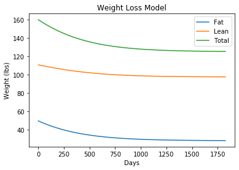

```python
height = (5 + 8/12) * 0.3048 # 5 ft 8 in to meters conversion
BW = 160 * 0.45359237 # 160 lbs to kg
# Get initial condition
F0 = fat_mass(BW, 38, height, "female")
L0 = BW - F0

K = (1 / PAL_0 - beta_AT) * EI_0 - gamma_f * F0 - gamma_l * L0

t = np.linspace(0, 1825, 1825)
sol = odeint(weight_odesystem, [F0, L0], t)
weight_sol = sol[:, 0] + sol[:,1]
plt.figure(2)
plt.plot(t, sol[:, 0] * 2.20462262, label="Fat")
plt.plot(t, sol[:, 1] * 2.20462262, label="Lean")
plt.plot(t, weight_sol * 2.20462262, label="Total")
plt.xlabel("Days")
plt.ylabel("Weight (lbs)")
plt.title("Weight Loss Model")
plt.legend()
plt.show()
```

# Problem 7

Modify the preceding problem to handle a two stage weightloss intervention: Suppose for the first 16 weeks intake is reduced from 2143 to 1600 calories/day and physical activity is increased from little to no exercise (PAL=1.4) to an hour of exercise 5 days per week (PAL=1.7). The following 16 weeks intake is increased from 1600 to 2025 calories/day, and exercise is limited to only 2-3 days per week (PAL=1.5).

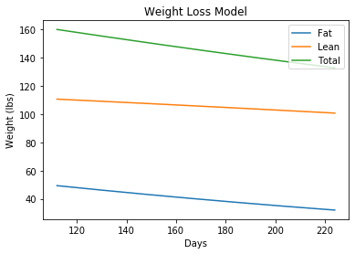

```python
# Set Constants
gamma_f, gamma_l, nf, nl, beta_AT = 3.2, 22, 180, 230, 0.14
pl, pf = 1800, 9400
EI_0 = 2143
PALs = [1.4, 1.7]
diet_len = 7 *16

# Each iteration in for loop is a diet strategy (2 total)
for i, (PAL, EI) in enumerate([(1.7, 1600), (1.5, 2025)]):

    if i == 0:
        BW = 160 * 0.45359237 # 160 lbs to kg
        t = np.linspace(0, diet_len, 1000)
    else:
        BW = (sol[-1,0] + sol[-1, 1]) / 0.45359237 # kg to lbs
        t = np.linspace(diet_len, diet_len * 2, 1000)

    height = (5 + 8/12) * 0.3048 # 5 ft 8 in to meters conversion
    PAL_0 = PALs[i]
    F0 = fat_mass(BW, 38, height, "female")
    L0 = BW - F0
    K = (1 / PAL_0 - beta_AT) * EI_0 - gamma_f * F0 - gamma_l * L0

    def forbes(F):
        C = (10.4 * pl) / pf
        return C / (C + F)

    def energy_balance(F, L, PAL, EI):
        numer = (1 / PAL - beta_AT) * EI - K - gamma_f * F - gamma_l * L
        denom = (nf / pf) * (1 - forbes(F)) + (nl / pl) * forbes(F) + 1 / PAL
        return numer / denom

    def weight_odesystem(y, t):
        F, L = y
        first_entry = ((1 - forbes(F)) * energy_balance(F, L, PAL, EI)) / pf
        second_entry = forbes(F) * energy_balance(F, L, PAL, EI) / pl
        return (first_entry, second_entry)

    if i == 0:
        sol = odeint(weight_odesystem, [F0, L0], t)
    else:
        # Stack the first solution on top of the second
        sol = np.hstack([sol, odeint(weight_odesystem, [F0, L0], t)])
    weight_sol = sol[:, 0] + sol[:,1]

# Plot the solution
plt.figure(3)
plt.plot(t, sol[:, 0] * 2.20462262, label="Fat")
plt.plot(t, sol[:, 1] * 2.20462262, label="Lean")
plt.plot(t, weight_sol * 2.20462262, label="Total")
plt.xlabel("Days")
plt.ylabel("Weight (lbs)")
plt.title("Weight Loss Model")
plt.legend()
plt.show()
```